# Lending Club Loans' Default Prediction--By Clara Liu

# revol_ving Line Utilization Rate

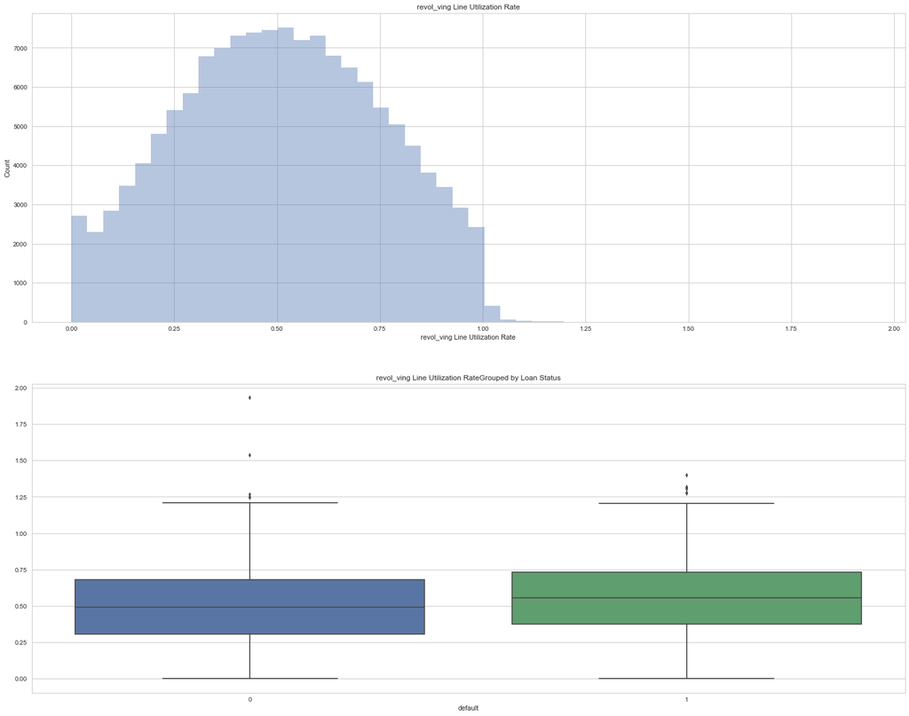

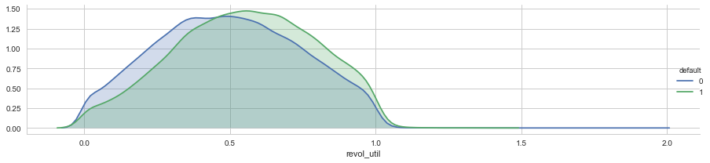

```python
plot_var('revol_util','revol_ving Line Utilization Rate', True)
```

# Initial List Status

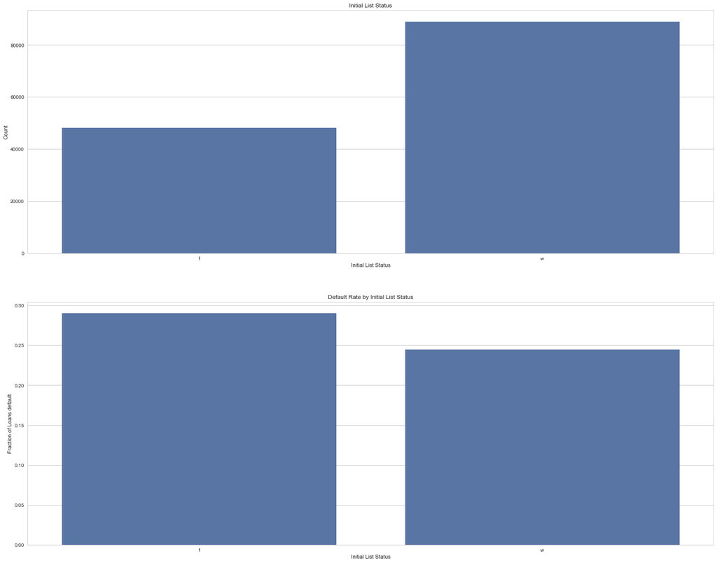

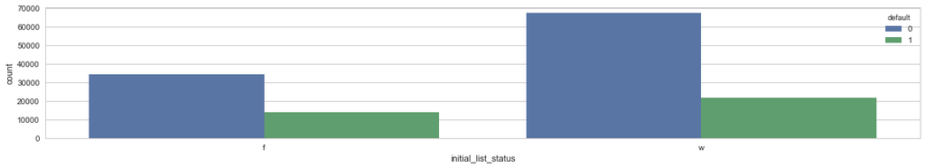

```python
plot_var('initial_list_status','Initial List Status', False)
```

# Policy Code

```python
df['policy_code'].value_counts()
```

```
1    137035
Name: policy_code, dtype: int64
```

All records have the same value so I dropped this column.

```python
df.drop('policy_code',axis=1,inplace=True)
```

# Application Type

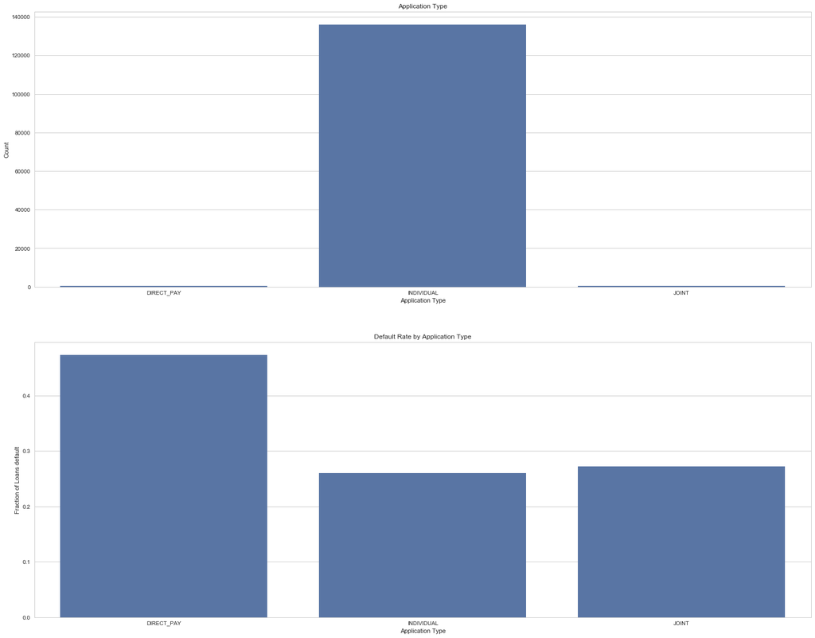

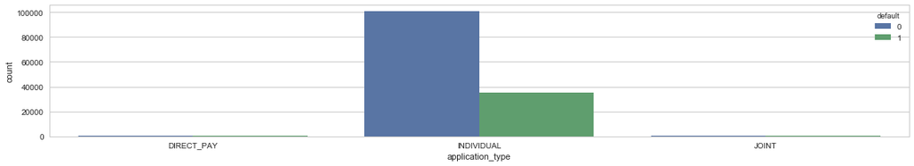

```python
plot_var('application_type','Application Type',False)
```

# 5. Feature Engineering

Now we have the cleaned data. The next step is to prepare the data for medeling. This includes transferring categorical data to one hot encoding features, randomly split training and testing data, filling in missing values and standardization of features (For some machine learning algorithms wwhich are affected by the range of the features we need to insure that they are all on the same scale).

```python
df.columns
```

```
Index(['loan_id', 'loan_amnt', 'term', 'int_rate', 'installment', 'emp_title',
       'emp_length', 'home_ownership', 'annual_inc', 'verification_status',
       'loan_status', 'purpose', 'zip_code', 'addr_state', 'dti',
       'earliest_cr_line', 'pub_rec', 'revol_bal', 'revol_util',
       'initial_list_status', 'application_type', 'total_rev_hi_lim',
       'default', 'group_emp_title'],
      dtype='object')
```

```python
df.drop(['emp_title','loan_status','loan_id'],1,inplace=True)
df.columns
```

```
Index(['loan_amnt', 'term', 'int_rate', 'installment', 'emp_length',
       'home_ownership', 'annual_inc', 'verification_status', 'purpose',
       'zip_code', 'addr_state', 'dti', 'earliest_cr_line', 'pub_rec',
       'revol_bal', 'revol_util', 'initial_list_status', 'application_type',
       'total_rev_hi_lim', 'default', 'group_emp_title'],
      dtype='object')
```

# 5.1 Encoding for Categorical Features

```python
df.head()
```

|  | loan_amnt | term | int_rate | installment | emp_length | home_ownership | annual_inc | verification_status | purpose | zip_code | ... | dti | earliest_cr_line | pub_rec | revol_bal | revol_util | initial_list_status | application_type | total_rev_hi_lim | default | group_emp_title |
| --- | --- | --- | --- | --- | --- | --- | --- | --- | --- | --- | --- | --- | --- | --- | --- | --- | --- | --- | --- | --- | --- |
| 0 | 25000 | 36 | 0.0749 | 6.657433 | 10.0 | MORTGAGE | 11.599112 | Not Verified | debt_consolidation | 226 | ... | 26.02 | 37226 | 0.0 | 9.945733 | 0.543 | w | INDIVIDUAL | 38400 | 0 | other purpose |
| 1 | 23975 | 60 | 0.1989 | 6.453200 | 10.0 | RENT | 11.156265 | Not Verified | credit_card | 220 | ... | 33.20 | 34851 | 0.0 | 10.710142 | 0.949 | w | INDIVIDUAL | 47200 | 1 | other purpose |
| 6 | 20000 | 36 | 0.0980 | 6.468428 | 5.0 | RENT | 11.225257 | Not Verified | debt_consolidation | 984 | ... | 23.45 | 33725 | 0.0 | 8.930494 | 0.096 | w | INDIVIDUAL | 78900 | 0 | other purpose |
| 7 | 15000 | 60 | 0.1344 | 5.845542 | 4.0 | RENT | 11.254336 | Source Verified | credit_card | 347 | ... | 18.17 | 37226 | 1.0 | 10.989319 | 0.258 | w | INDIVIDUAL | 80500 | 0 | other purpose |
| 9 | 15000 | 36 | 0.0849 | 6.162156 | 6.0 | MORTGAGE | 11.608245 | Not Verified | credit_card | 85 | ... | 13.24 | 37591 | 1.0 | 9.853772 | 0.414 | w | INDIVIDUAL | 46000 | 0 | other purpose |

5 rows × 21 columns

Create a function to find categorical features and transfer them

```python
categorical_features = []
def cate_encode(data):
    for i in data.columns:
        if data[i].dtype.name == 'object' and i != 'default':
            categorical_features.append(i)
            print(i)
            data[i].fillna('No '+ i, inplace=True)
            encode = pd.DataFrame(LabelBinarizer().fit_transform(data[i]),columns=sorted(data[i].unique()))
            data.drop(i,axis=1,inplace=True)
            data=pd.concat([data, encode], axis=1)
    return data
df = cate_encode(df)
```

```
home_ownership
verification_status
purpose
addr_state
initial_list_status
application_type
group_emp_title
```

```python
df.drop([column for column in df.columns if 'no ' in column.lower()], axis = 1, inplace = True)
```

```python
df = df[(df['default']==1) | (df['default']==0)]
```

```python
#convert 'default' to number
df['default']=df['default'].apply(lambda x: int(x))
```

Cuurent columns:

```python
print(df.columns,'In total '+ str(len(df.columns))+' columns')
```

```
Index(['loan_amnt', 'term', 'int_rate', 'installment', 'emp_length',
       'annual_inc', 'zip_code', 'dti', 'earliest_cr_line', 'pub_rec',
       'revol_bal', 'revol_util', 'total_rev_hi_lim', 'default', 'MORTGAGE',
       'OWN', 'RENT', 'Not Verified', 'Source Verified', 'Verified', 'car',
       'credit_card', 'debt_consolidation', 'home_improvement',
       'major_purchase', 'medical', 'moving', 'other purpose',
       'small_business', 'AK', 'AL', 'AR', 'AZ', 'CA', 'CO', 'CT', 'DC', 'DE',
       'FL', 'GA', 'HI', 'ID', 'IL', 'IN', 'KS', 'KY', 'LA', 'MA', 'MD', 'ME',
       'MI', 'MN', 'MO', 'MS', 'MT', 'NC', 'ND', 'NE', 'NH', 'NJ', 'NM', 'NV',
       'NY', 'OH', 'OK', 'OR', 'PA', 'RI', 'SC', 'SD', 'TN', 'TX', 'UT', 'VA',
       'VT', 'WA', 'WI', 'WV', 'WY', 'f', 'w', 'DIRECT_PAY', 'INDIVIDUAL',
       'JOINT', 'agent', 'assistant', 'business manager', 'business owner',
       'business senior manager', 'driver', 'engineer', 'lawyer',
       'nurse & doctor', 'officer', 'other purpose', 'sales', 'teacher',
       'technical employee', 'technician', 'unkown employment'],
      dtype='object') In total 100 columns
```

# 5.2 Split Training and Test Data

Here I randomly split training data and testing data. The proportion is 0.75 and 0.25.

```python
features=df.drop('default',1)
labels=df['default']
X_train, X_test, y_train, y_test = train_test_split(features,labels, test_size=0.25, random_state=0)
```

# 5.3 Fill in Missing Values

I filled in missing values with training data's median in both training data and testing data to prevent test data leakage.

```python
#create an imputer with a median filling strategy
imputer = Imputer(strategy='median')

# Train on the training features
imputer.fit(X_train)

# Transform both training and testing data
X_train = pd.DataFrame(imputer.transform(X_train), columns=X_train.columns)
X_test = pd.DataFrame(imputer.transform(X_test), columns=X_test.columns)
```

Check missing values

```python
sum(X_train.isnull().sum())
```

```
0
```

```python
sum(X_test.isnull().sum())
```

```
0
```

# 5.4 Feature Scaling

```python
# Create a scaler
scaler = StandardScaler()

# Train on the training features
scaler.fit(X_train)

# Transform training and testing data
X_train = pd.DataFrame(scaler.transform(X_train), columns = X_train.columns)
X_test = pd.DataFrame(scaler.transform(X_test), columns = X_test.columns)
```

Now our data should be ready for modeling!